# Food and You analyses_enviroment impact 27112023

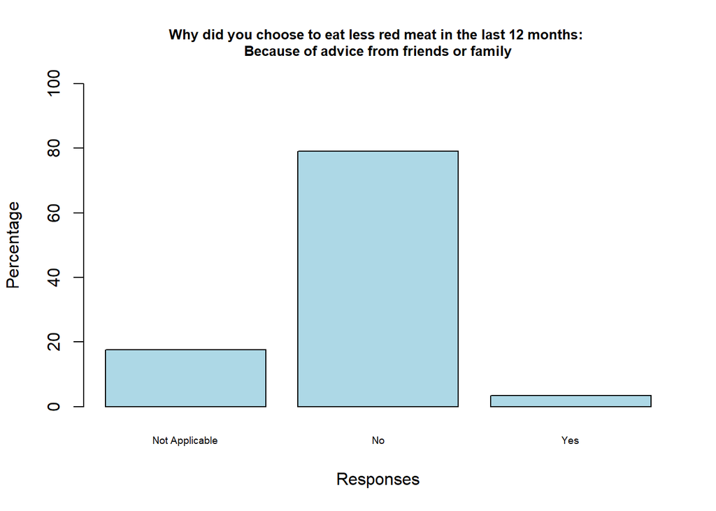

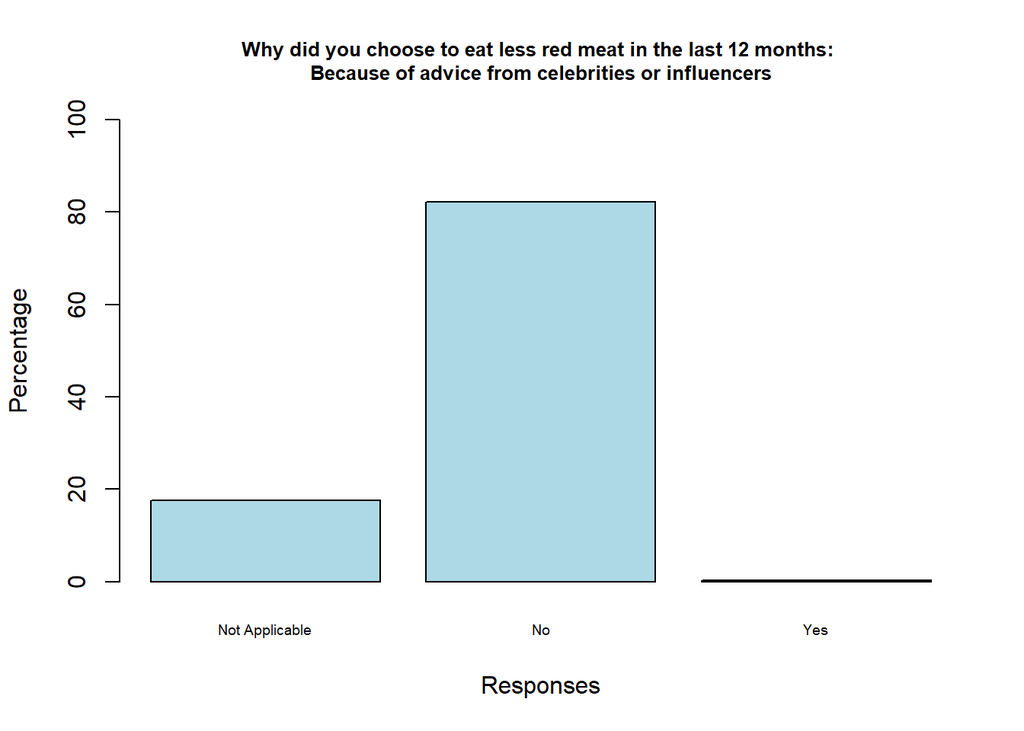

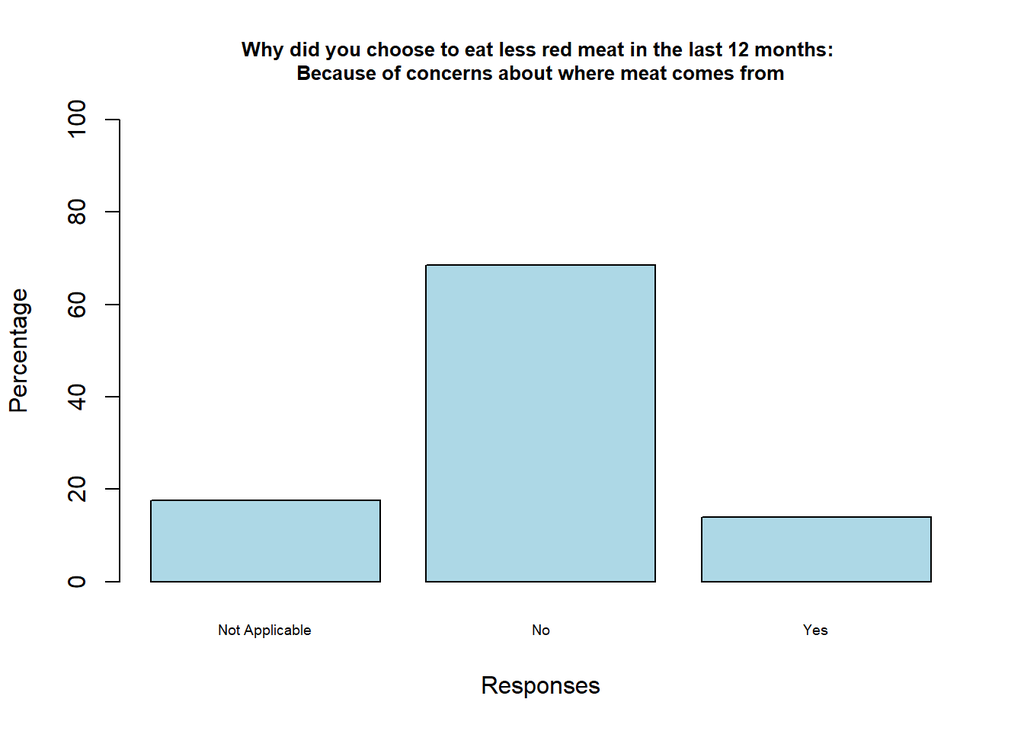

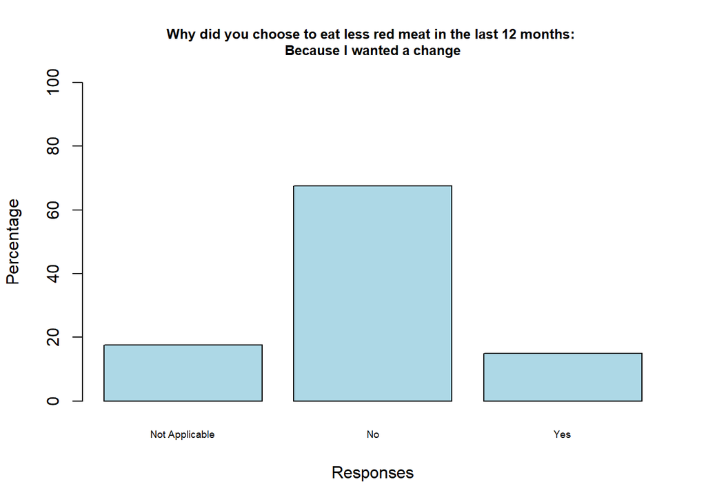

[4 more figures not shown]

## Why did you choose to eat less or more in the last 12 months

I have not analised these question, few cases.

```
## [1] 455
```

## Which changes are you willing to try in the next 12 months:

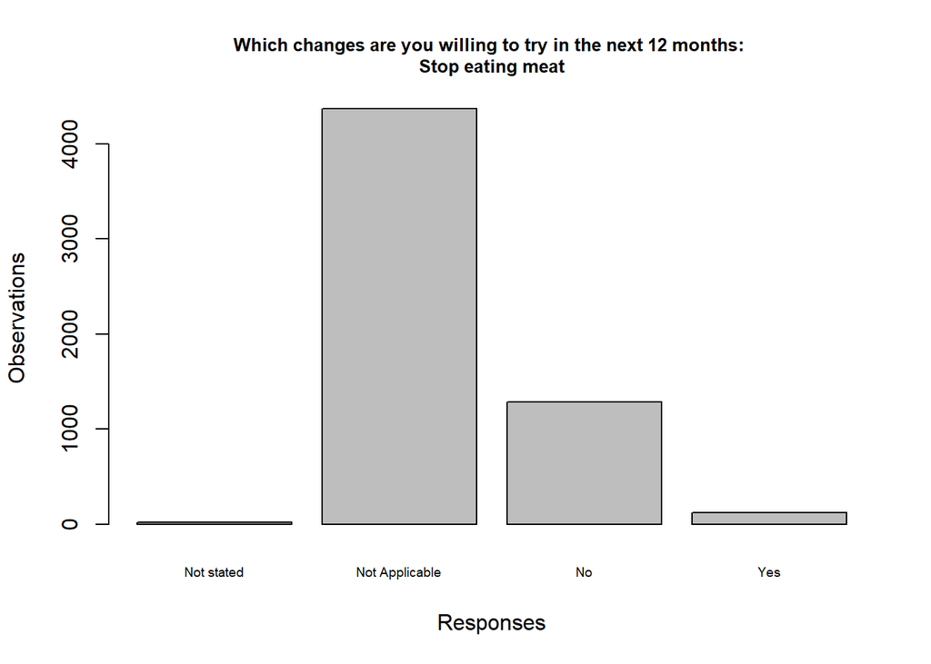

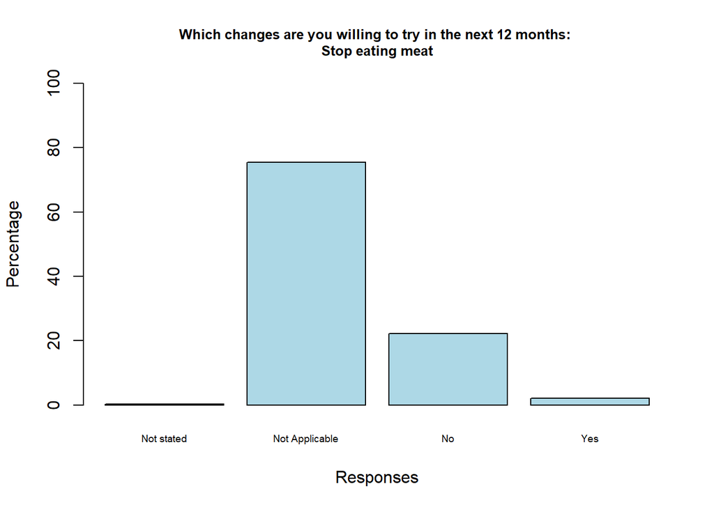

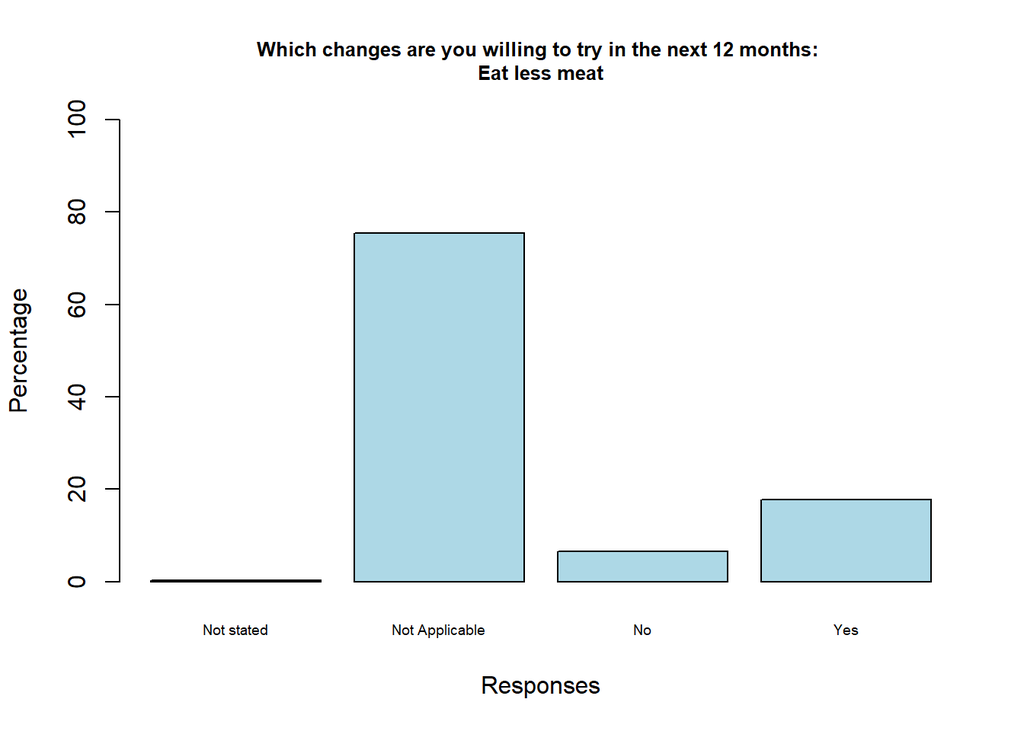

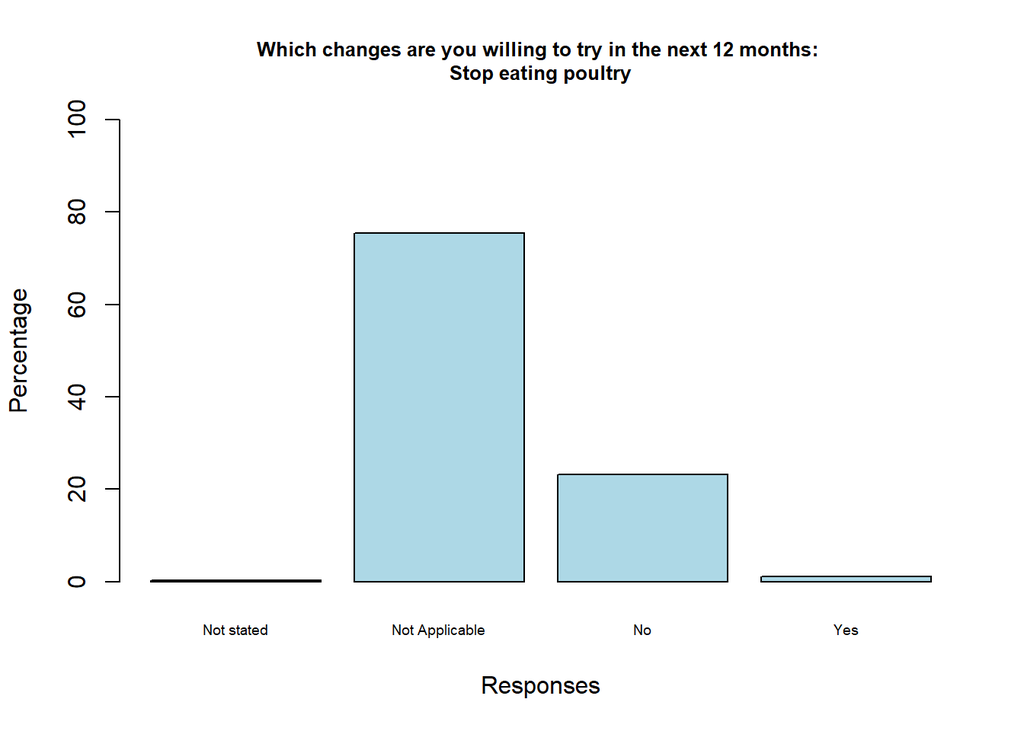

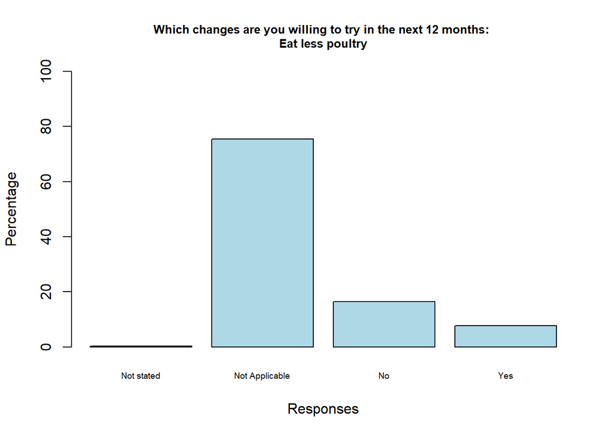

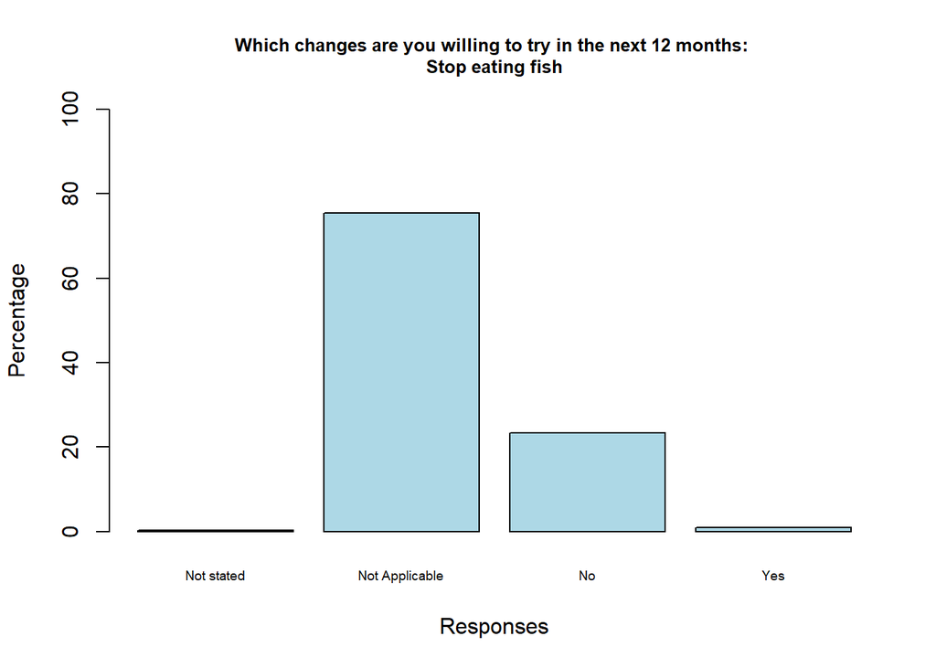

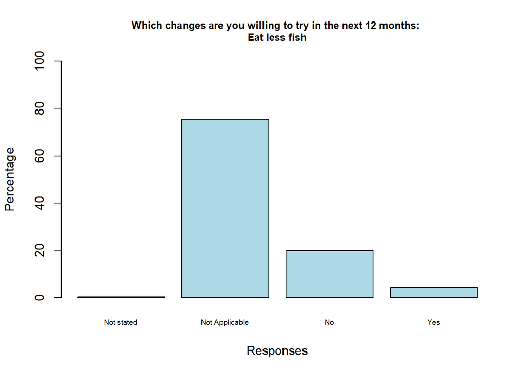

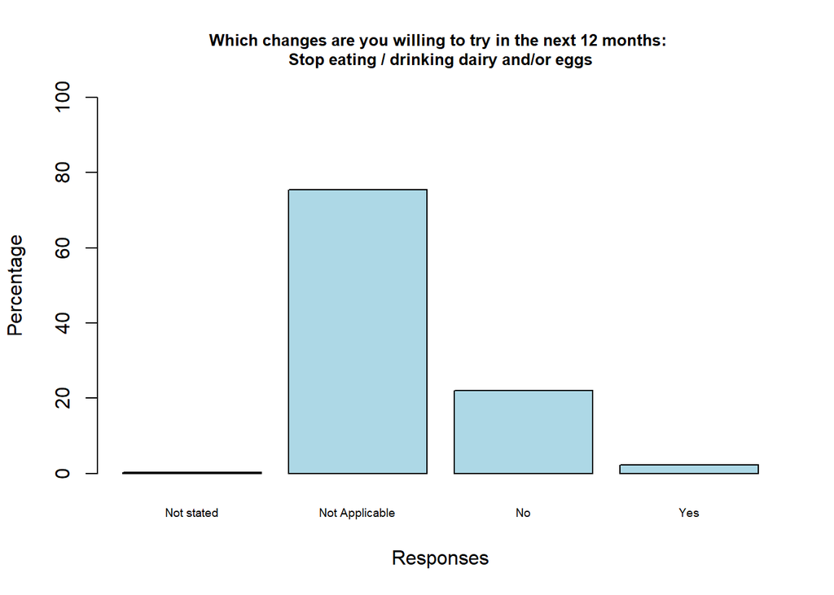

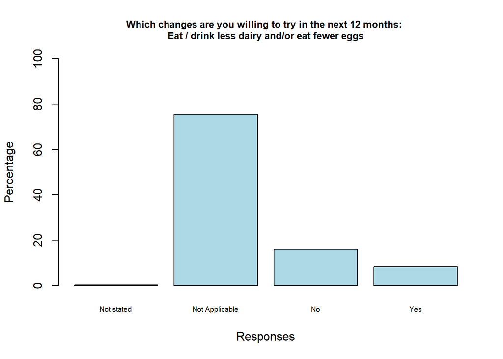

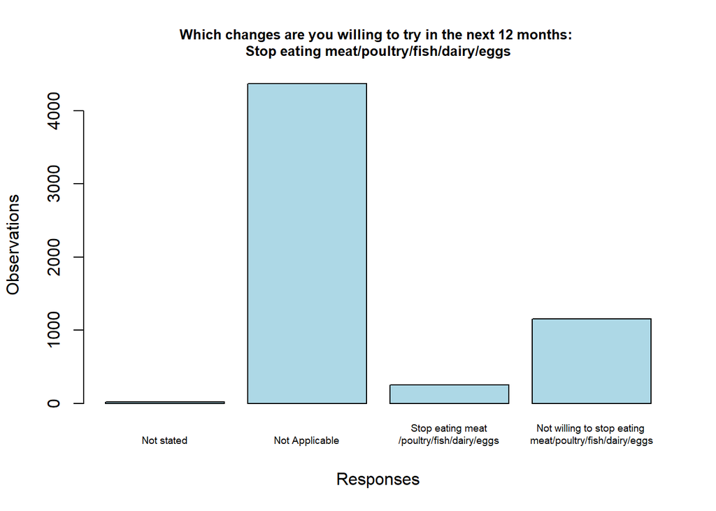

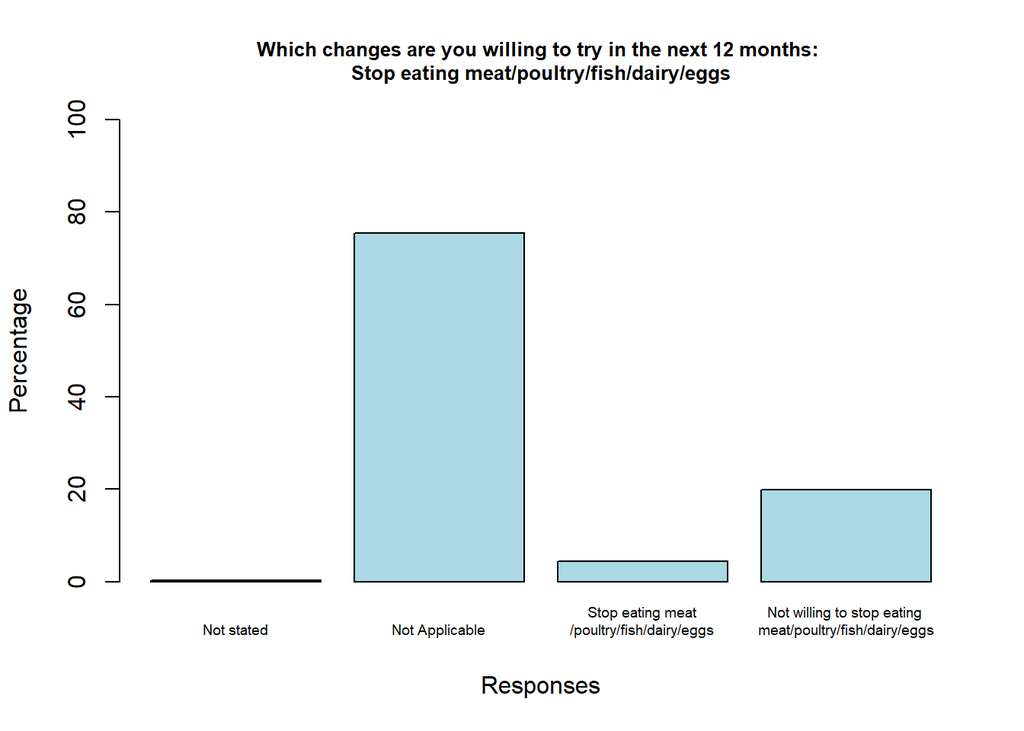

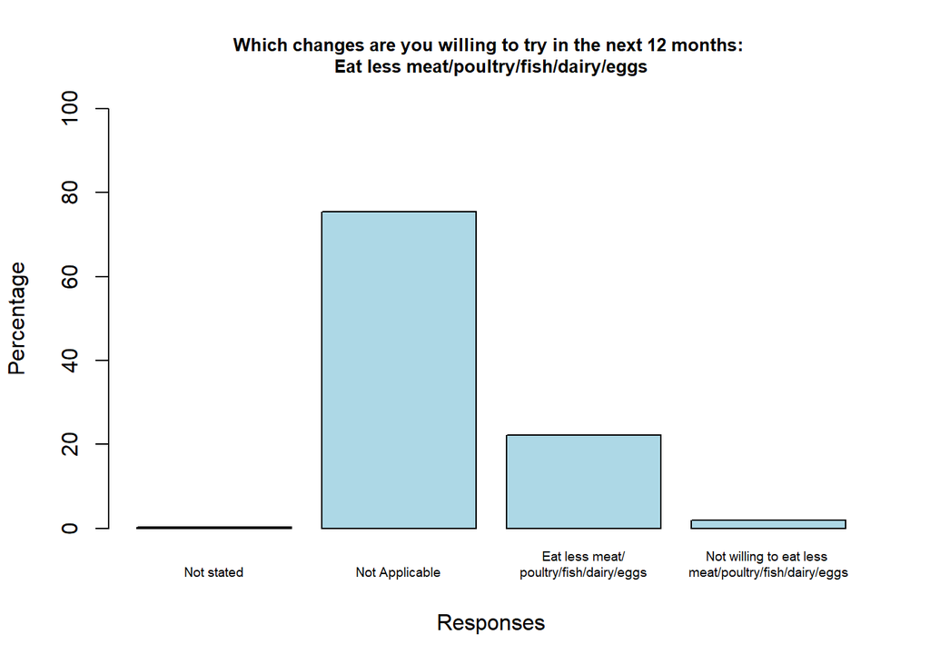

## Why are you willing to try to stop eating / eat less meat in the next 12 months

I have not analised these questions. Few cases.

```
## [1] 455
```

## Which of the following reasons explain why you choose to eat meat alternative

I have not analised all the questions in this section. The questions are:

Have you ever eaten meat alternatives?, Which of the following reasons explain why you choose to eat meat alternatives (MULTIPLE RESPONSES), Would you like to eat more meat alternatives?, Would you like to try eating meat alternatives?, In general, how healthy do you think shop-bought meat alternatives are compared to meat? (A LIST OF SIMILAR QUESTIONS), Would you like to try including lab-grown meat in your diet, if it became available in this country?, Have you ever heard of Genetically modified (GM) food?, Have you ever heard of Gene edited or genome edited food?

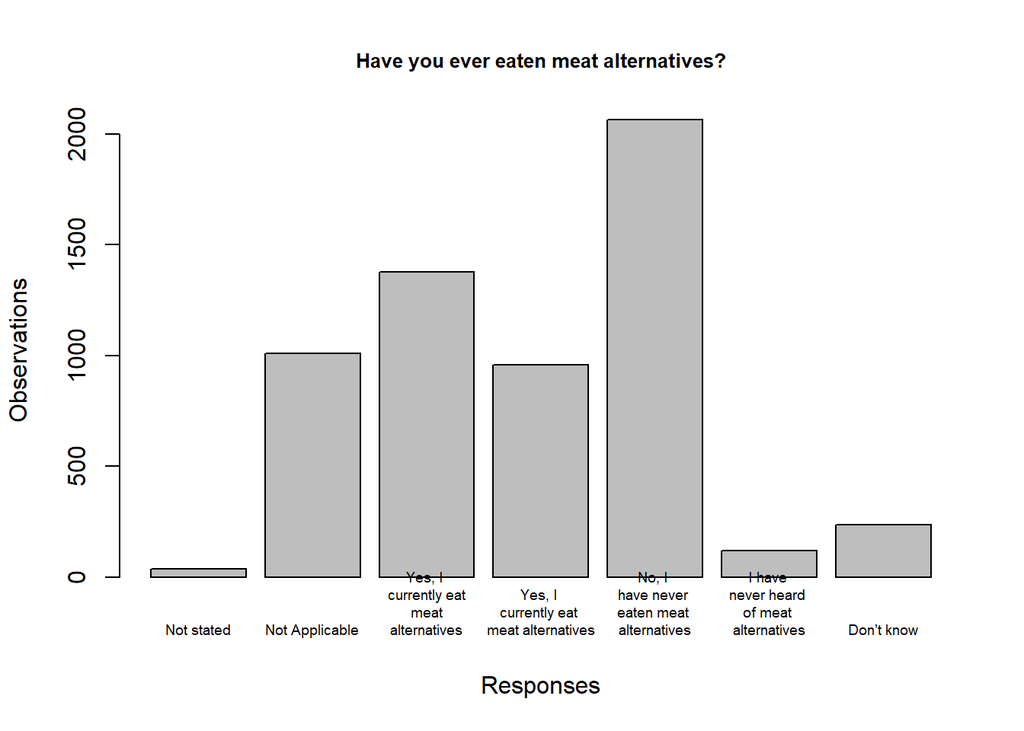

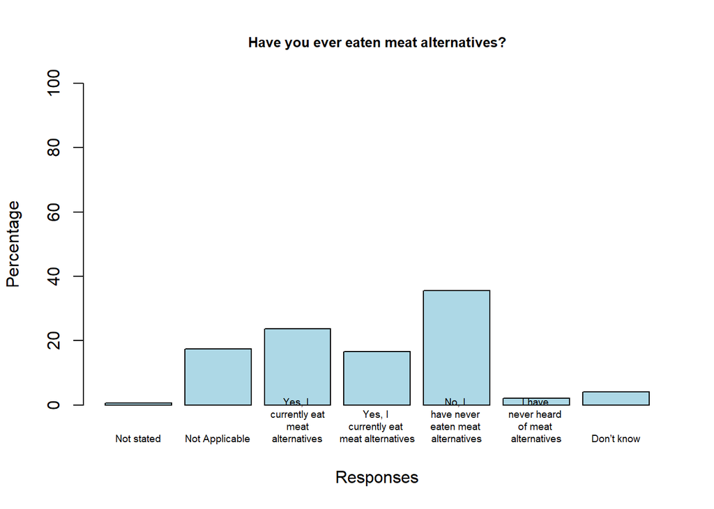

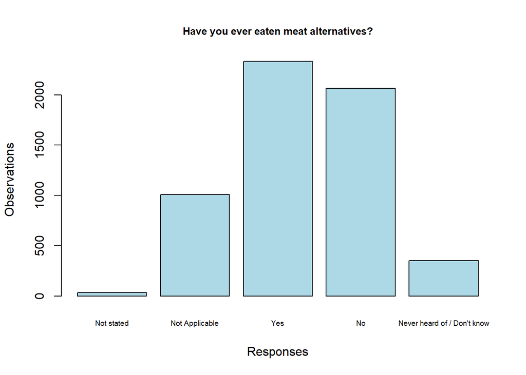

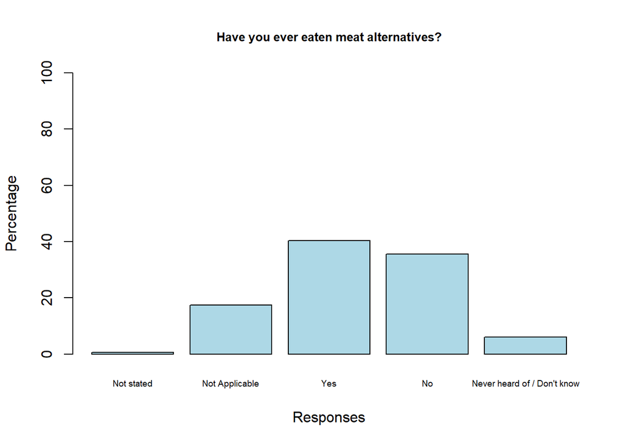